# Final Project: Is College Worth It? (Tuition VS Salary)

Junjie Yang

5/2/2020

# I. Introduction

Is college worth it? Is college a good investment for your future? If it is, what kind of factors in college would have an impact on career performance?

On one hand, college could be worth it by leading to higher employment rates and higher career performance, in terms of various financial measurements, than people who do not go to college. On the other hand, college tuition is constantly rising and is the same for student loan debt.

In this project, four data sources are acquired from the US Department of Education, the Chronicle of Higher Education, the National Center for Education Statistics, and payscale.com. A final dataset in tidy version is created by conducting a significant amount of data cleansing and data wrangling techniques, so as to retrieve insightful information regarding the relationship between tuition or other factors in college and future career performance of college graduates.

## Github Link

(Include several Data in tidy version, Rmd File, Report in PDF File and HTML File)

### URL to clone: (https://github.com/Junjie-Dylan-Yang/Data-Wrangling-Project.git)

### URL to repository: (https://github.com/Junjie-Dylan-Yang/Data-Wrangling-Project)

# II. ETL process: Data Import and Data Cleansing

## 1,

### Import first data: tuition_cost

First data source, tuition_cost, contains information of tuition and fees by college/university along with school type, degree length, stateis. It is from “College tuition, Diversity, and Pay” in rfordatascience/tidetuesday/2020-03-10, which is originally acquired from the US Department of Education and the Chronicle of Higher Education.

### Data Cleaning for tuition_cost data

In the tuition_cost data, relevant columns are selected (name of the school, state, state code, type of the school, length of the degree). Also, room and board fee and tuition are combined as total tuition and fee.

### Below is the snippet of tuition_cost data

| name | state | state_code | type | degree_length | in_state_tuition_and_fee | out_of_state_tuition_and_fee |
| --- | --- | --- | --- | --- | --- | --- |
| Aaniiih Nakoda College | Montana | MT | Public | 2 Year | 2380 | 2380 |
| Abilene Christian University | Texas | TX | Private | 4 Year | 45200 | 45200 |
| Abraham Baldwin Agricultural College | Georgia | GA | Public | 2 Year | 12602 | 21024 |
| Academy College | Minnesota | MN | For Profit | 2 Year | 17661 | 17661 |
| Academy of Art University | California | CA | For Profit | 4 Year | 44458 | 44458 |
| Adams State University | Colorado | CO | Public | 4 Year | 18222 | 29238 |
| Adelphi University | New York | NY | Private | 4 Year | 54690 | 54690 |
| Adirondack Community College | New York | NY | Public | 2 Year | 17035 | 21595 |
| Adrian College | Michigan | MI | Private | 4 Year | 48405 | 48405 |
| Advanced Technology Institute | Virginia | VA | For Profit | 2 Year | 13680 | 13680 |

## 2,

### Import second data: student_diversity

Second data source, student_diversity by college/university, along with information about enrollment and race, is from the Chronicle of Higher Education.

### Data Cleaning for student_diversity data

In the student_diversity data, the main data cleansing task is to modify name of institution to match the “name” column and “state” column in the tuition_cost data, in order to combine dataset. Several data wrangling steps are applied. First is to change the column name “INSTITUTION” to “name”. After that, convert any abbreviation of University from “U.” to “University”. From the first glance, the name of state is located at the very end of the name of institution. The next step is to extract state from school name with the help of state.name which contains the list of all the state name and column “state” is created. Last but not least, state name inside the name of institution needed to remove. Using str_count to count the letters within state in each observation and str_sub help to keep the name of school only in the “name” column. Str_trim and str_squish are used to remove unnecessary spaces in “name”.

### Below is the snippet of student_diversity_cleaned data

| name | ENROLLMENT | WOMEN | AMERICAN INDIAN / ALASKA NATIVE | ASIAN | BLACK | HISPANIC | NATIVE HAWAIIAN / PACIFIC ISLANDER | WHITE | TOTAL MINORITY | state |
| --- | --- | --- | --- | --- | --- | --- | --- | --- | --- | --- |
| University of Phoenix-Arizona | 195059 | 134722 | 876 | 1959 | 31455 | 13984 | 1019 | 58209 | 68332 | Arizona |
| Ivy Tech Community College-Central Indiana | 91179 | 53476 | 357 | 1369 | 12370 | 5533 | 0 | 61498 | 21433 | Indiana |
| Liberty University | 81459 | 48329 | 447 | 856 | 14751 | 1186 | 151 | 39062 | 19163 | Virginia |
| Lone Star College system | 69395 | 41268 | 168 | 4198 | 12094 | 23751 | 0 | 23615 | 42208 | Texas |
| Miami Dade College | 66046 | 38323 | 47 | 655 | 10722 | 44870 | 41 | 4170 | 56561 | Florida |
| Grand Canyon University | 62304 | 46647 | 586 | 2446 | 13856 | 8933 | 295 | 28715 | 27674 | Arizona |
| Texas A&M University at College Station | 61642 | 29277 | 173 | 3545 | 1879 | 11256 | 59 | 37458 | 18556 | Texas |
| University of Central Florida | 60767 | 33482 | 120 | 3343 | 6400 | 13108 | 129 | 33293 | 24941 | Florida |
| Ohio State University | 58322 | 28658 | 76 | 3339 | 3108 | 2049 | 35 | 40283 | 10110 | Ohio |
| Houston Community College | 58276 | 34007 | 116 | 5391 | 18520 | 18411 | 130 | 8368 | 43448 | Texas |

### Combine tuition_cost and student_diversity data based on “name” and “state”

So far, student_diversity and tuition_cost are modified to share two common column, “name” – name of the school and “state” – the state that the school is located. Thus, student_diversity and tuition_cost datasets are merged for later development. There are a few schools appears in the tuition_cost dataset but not in the student_diversity and results in “NA” value appearance. It is reasonable and schools with “NA” value are removed from the combined dataset. The combined dataset is arranged by state and the name of the school.

### Below is the snippet of the combined dataset, tuition_with_diversity

| name | state | state_code | type | degree_length | in_state_tuition_and_fee | out_of_state_tuition_and_fee | ENROLLMENT | WOMEN | AMERICAN INDIAN / ALASKA NATIVE | ASIAN | BLACK | HISPANIC | NATIVE HAWAIIAN / PACIFIC ISLANDER | WHITE | TOTAL MINORITY |
| --- | --- | --- | --- | --- | --- | --- | --- | --- | --- | --- | --- | --- | --- | --- | --- |
| Alabama Southern Community College | Alabama | AL | Public | 2 Year | 4440 | 8880 | 1398 | 853 | 13 | 7 | 608 | 7 | 0 | 742 | 645 |
| Alabama State University | Alabama | AL | Public | 4 Year | 16490 | 24818 | 5519 | 3430 | 8 | 20 | 4950 | 68 | 3 | 208 | 5105 |
| Amridge University | Alabama | AL | Private | 4 Year | 6900 | 6900 | 625 | 372 | 0 | 4 | 255 | 5 | 0 | 181 | 264 |
| Athens State University | Alabama | AL | Public | 4 Year | 6810 | 12870 | 3128 | 2046 | 48 | 17 | 396 | 63 | 3 | 2423 | 581 |
| Auburn University | Alabama | AL | Public | 4 Year | 24608 | 43856 | 25912 | 12798 | 183 | 601 | 1886 | 599 | 0 | 20855 | 3269 |
| Auburn University at Montgomery | Alabama | AL | Public | 4 Year | 17268 | 29028 | 5057 | 3233 | 23 | 104 | 1633 | 36 | 9 | 2572 | 1941 |
| Bevill State Community College | Alabama | AL | Public | 2 Year | 6070 | 9940 | 3609 | 2243 | 6 | 14 | 533 | 50 | 0 | 2922 | 634 |
| Birmingham-Southern College | Alabama | AL | Private | 4 Year | 30000 | 30000 | 1185 | 550 | 12 | 62 | 130 | 23 | 0 | 946 | 233 |
| Bishop State Community College | Alabama | AL | Public | 2 Year | 4740 | 8610 | 3320 | 1974 | 23 | 55 | 2113 | 63 | 7 | 946 | 2301 |
| Calhoun Community College | Alabama | AL | Public | 2 Year | 4840 | 8690 | 10802 | 6045 | 186 | 374 | 1942 | 458 | 7 | 7170 | 3394 |

## 3,

### Import third data: Best_School

Third data source, best_school is html data, acquired from the from the payscale.com. It contains all the schools in United States that are arranged by various measurement of career performance, such as “Early Career Pay” and "Mid Career Pay.

#### Problem encountered

When importing html data from https://www.payscale.com/college-salary-report/bachelors, I realized that it only shows the first page of the table and the table only include the data with the top 25 schools in the United States, descending by measurement of career performance. That’s the issue that I am not expecting. Moreover, this is the first page in the web and there are 63 pages in total, which consists all the school data.

#### Problem resolved

Instead of importing data 63 times from different urls to get the entire dataset, one alternative webpage is found by navigating the payscale.com. The page “Best Schools By State” (https://www.payscale.com/college-salary-report/best-schools-by-state) outlays all the best schools ranked by measurement of career performance of all 50 states. Clicking on each state would direct to the schools data within that particular state. In order to import the entire data, I first convert the string format in the list of state.name to match the url format (for example, “New York” to “New-York”). Then, a data frame is created. For-Loop is implemented to import all 50 states data to the R environment and to keep loading data into the data frame to complete the entire dataset of all 50 states, “Best_School”, for data cleansing.

### Data Cleaning for Best_School data

First step is to modify the column name “School Name” to “name” and to keep the exact name of school only, in order to match the previous combined tuition_with_diversity dataset for binding. After that, there are several data cleansing steps that are applied to other columns. Only numeric values are extracted from the columns, “Rank”, “Early Career Pay”, “Mid-Career Pay”, “% High Meaning”, “% STEM Degrees”. One lesson learned is that R suggests to use parse_number(), instead of extract_numeric() for extracting numeric value.

### Below is the snippet of Best_School_clean data

|  | name | Early Career Pay | Mid-Career Pay | % High Meaning | % STEM Degrees |
| --- | --- | --- | --- | --- | --- |
| 1 | Auburn University | 54400 | 104500 | 51 | 31 |
| 2 | University of Alabama in Huntsville | 57500 | 103900 | 59 | 45 |
| 3 | The University of Alabama | 52300 | 97400 | 50 | 15 |
| 4 | Tuskegee University | 54500 | 93500 | 61 | 30 |
| 5 | Samford University | 48400 | 90500 | 52 | 3 |
| 6 | Spring Hill College | 46600 | 89100 | 53 | 12 |
| 7 | Birmingham Southern College | 49100 | 88300 | 48 | 27 |
| 8 | University of Alabama at Birmingham | 48600 | 87200 | 57 | 17 |
| 9 | University of South Alabama | 47700 | 86400 | 56 | 17 |
| 10 | Alabama A & M University | 48700 | 83500 | 58 | 20 |

### Combine Best_School_clean data and tuition_with_diversity to form the final data

Finally, Best_School_clean data, which contains different measurements of career performance, merges with tuition_with_diversity data, which contains detailed school information including tuition and race. The column both datasets have in common is “name” and left_join is performed. Similar to the previous merged dataset, schools with “NA” are removed from the dataset.

### Create new variables:

Early_career_pay_paidoff: difference between median salary for alumni with 0-5 years experience and out of state tuition and fee:

[Early Salary(0-5 Years Experience) - Total College Cost]

### Attribute Information

Below information is from payscale.com:

“Early Career Pay” is defined as median salary for alumni with 0-5 years experience.

“Mid-Career Pay” is defined as Median salary for alumni with 10+ years experience.

“% High Meaning” is defined as the percentage of alumni who say their work makes the world a better place.

“% STEM Degrees” is defined as the percentage of degrees awarded in science, technology, engineering or a math subjects.

|  | name | Early Career Pay | Mid-Career Pay | % High Meaning | % STEM Degrees | state | state_code | type | degree_length | in_state_tuition_and_fee | out_of_state_tuition_and_fee | ENROLLMENT | WOMEN | AMERICAN INDIAN / ALASKA NATIVE | ASIAN | BLACK | HISPANIC | NATIVE HAWAIIAN / PACIFIC ISLANDER | WHITE | TOTAL MINORITY | Mid_career_pay_paidoff | Early_career_pay_paidoff |
| --- | --- | --- | --- | --- | --- | --- | --- | --- | --- | --- | --- | --- | --- | --- | --- | --- | --- | --- | --- | --- | --- | --- |
| 1 | Auburn University | 54400 | 104500 | 51 | 31 | Alabama | AL | Public | 4 Year | 24608 | 43856 | 25912 | 12798 | 183 | 601 | 1886 | 599 | 0 | 20855 | 3269 | 60644 | 10544 |
| 2 | Tuskegee University | 54500 | 93500 | 61 | 30 | Alabama | AL | Private | 4 Year | 31820 | 31820 | 3103 | 1855 | 2 | 26 | 2345 | 32 | 0 | 52 | 2405 | 61680 | 22680 |
| 3 | Samford University | 48400 | 90500 | 52 | 3 | Alabama | AL | Private | 4 Year | 42200 | 42200 | 4933 | 3082 | 17 | 80 | 372 | 218 | 1 | 4007 | 738 | 48300 | 6200 |
| 4 | Spring Hill College | 46600 | 89100 | 53 | 12 | Alabama | AL | Private | 4 Year | 52926 | 52926 | 1376 | 820 | 10 | 16 | 210 | 77 | 1 | 947 | 359 | 36174 | -6326 |
| 5 | University of Alabama at Birmingham | 48600 | 87200 | 57 | 17 | Alabama | AL | Public | 4 Year | 17110 | 31030 | 18698 | 11288 | 46 | 931 | 3943 | 496 | 14 | 11840 | 5993 | 56170 | 17570 |
| 6 | University of South Alabama | 47700 | 86400 | 56 | 17 | Alabama | AL | Public | 4 Year | 17490 | 27360 | 15805 | 9700 | 100 | 539 | 3285 | 402 | 33 | 10102 | 4684 | 59040 | 20340 |
| 7 | Troy University | 44500 | 81500 | 60 | 8 | Alabama | AL | Public | 4 Year | 20645 | 31060 | 19041 | 11948 | 143 | 140 | 6840 | 666 | 19 | 9265 | 8294 | 50440 | 13440 |
| 8 | Jacksonville State University | 43800 | 80000 | 61 | 7 | Alabama | AL | Public | 4 Year | 18525 | 28245 | 8659 | 4978 | 61 | 50 | 2030 | 110 | 7 | 5934 | 2258 | 51755 | 15555 |
| 9 | Auburn University at Montgomery | 45000 | 79600 | 61 | 12 | Alabama | AL | Public | 4 Year | 17268 | 29028 | 5057 | 3233 | 23 | 104 | 1633 | 36 | 9 | 2572 | 1941 | 50572 | 15972 |
| 10 | Huntingdon College | 42400 | 78900 | 69 | 14 | Alabama | AL | Private | 4 Year | 37150 | 37150 | 1160 | 572 | 14 | 9 | 229 | 29 | 2 | 738 | 313 | 41750 | 5250 |

#### The tidy version of the final data, “Final_data” is saved under the name “Tidy_Final_Data.xlsx” local location and committed from Github desktop to Github.com repository (https://github.com/Junjie-Dylan-Yang/Data-Wrangling-Project)

## 4,

### Import fourth data: historical_tuition

The last data source, historical_tuition, is from “College tuition, Diversity, and Pay” in rfordatascience/tidetuesday/2020-03-10, which is originally acquired from the National Center for Education Statistics.(https://nces.ed.gov/fastfacts/display.asp?id=76)

The fourth data, historical_tuition, is tidy and contains the information of the trends in the cost of college education. Therfore, “historical_tuition“ is saved under the name of”Tuition_trend.xlsx" in the same location of The tidy version of the final data.

| type | year | tuition_type | tuition_cost |
| --- | --- | --- | --- |
| All Institutions | 1985-86 | All Constant | 10893 |
| All Institutions | 1985-86 | 4 Year Constant | 12274 |
| All Institutions | 1985-86 | 2 Year Constant | 7508 |
| All Institutions | 1985-86 | All Current | 4885 |
| All Institutions | 1985-86 | 4 Year Current | 5504 |
| All Institutions | 1985-86 | 2 Year Current | 3367 |
| All Institutions | 1995-96 | All Constant | 13822 |
| All Institutions | 1995-96 | 4 Year Constant | 16224 |
| All Institutions | 1995-96 | 2 Year Constant | 7421 |
| All Institutions | 1995-96 | All Current | 8800 |

# III. Data Analysis by Various Plot and Tables

After a series of data wrangling and data cleansing conducted on several data sources from above, final data in tidy version, “Final_data” and “historical_tuition” data are ready to use for data analysis.

## 1, Tuition Trend: Going upward over time

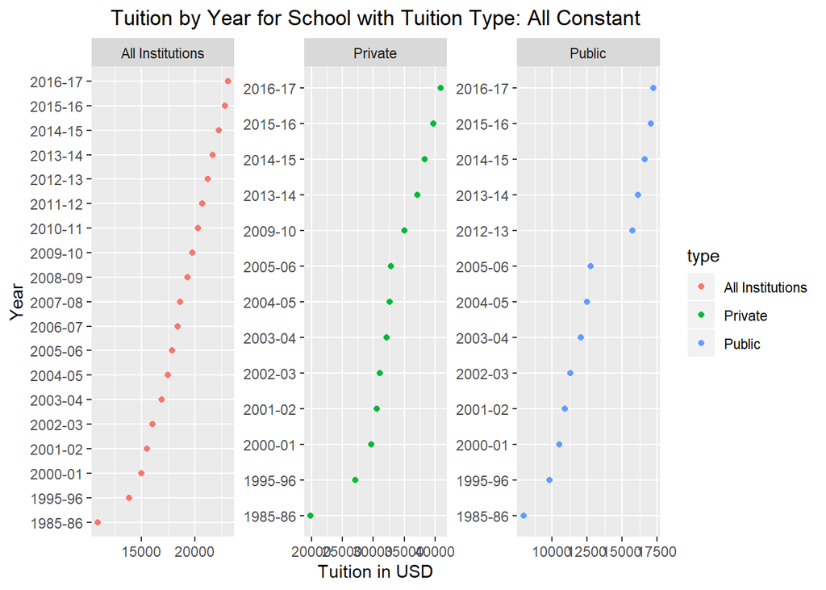

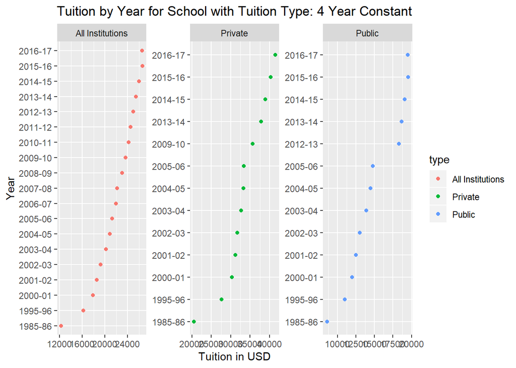

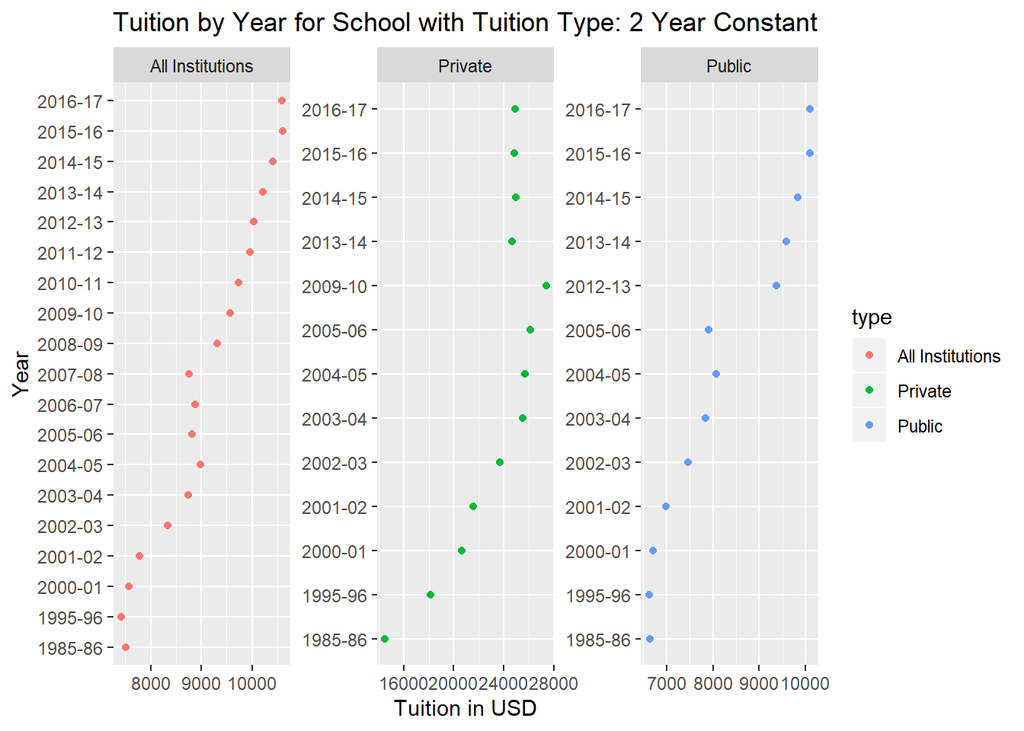

## 2, Take a look at the final data, “Final_data” at the level of states.

Create another dataset “state_data” at state level from the final data, “Final_data”. All numeric values are summarised by taking the average respect to each state. This dataset is also saved under the name “state_data.xlsx”, in the same location as the final data.

### Plots that show insightful information regarding tuition and career performance at the state level

1. As people expected, schools in big states like Pennsylvania, New York, California, and Massachusetts have the highest average out-of-state college cost because of high income and high levels of consumption rate.

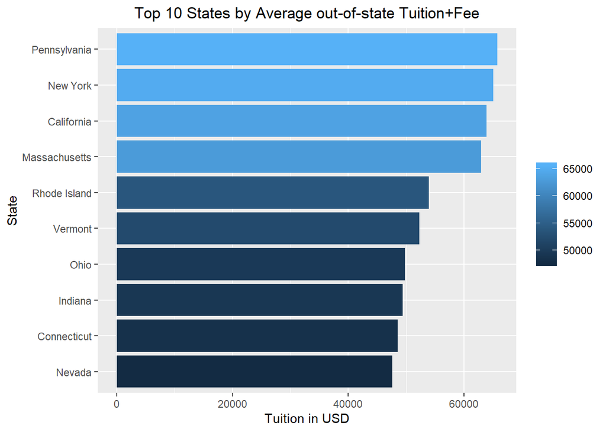

2. There is no suprise that people graduated from colleges/universities big states like Pennsylvania, New York, Massachusetts, and California would have better career performance in terms of early-salary pay (0-5 year experience) and mid-salary pay (10+ year experience) because schools in those states have the most wide range of education resources.

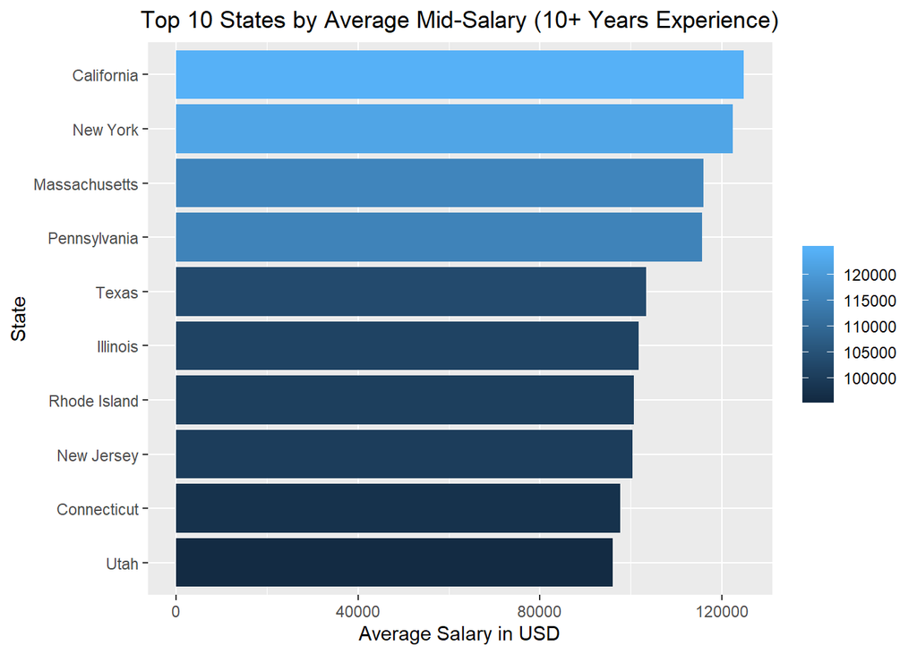

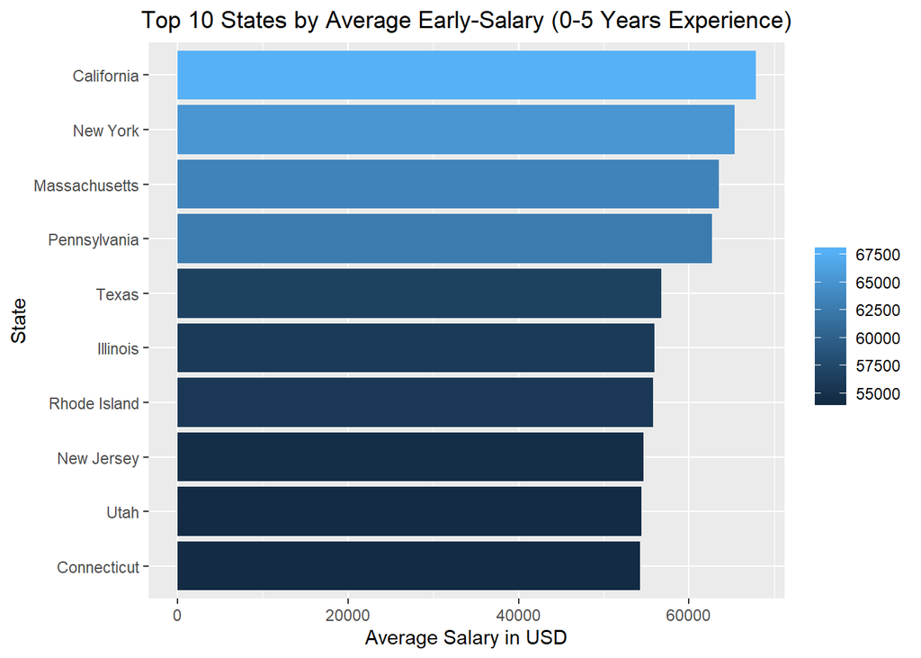

3. Interesting Finding:

If poeple consider going to college is a good investment and decide to go to the colleges in big states like Pennsylvania, New York, Massachusetts, and California based on the above plots of career performance in terms of salary, they should also take a look at the plots below.

“Mean_early_paidoff” and “Mean_mid_paidoff” are created based on “Early_career_pay_paidoff” and “Mid_career_pay_paidoff” during previous data cleansing steps in Part II.

They are defined as the average difference between median salary for alumni with 0-5 and 10+ years experience and out of state tuition and fee in different states.

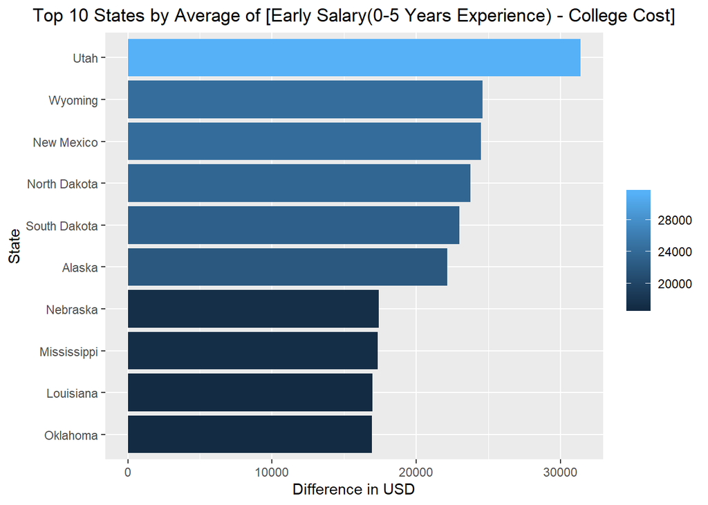

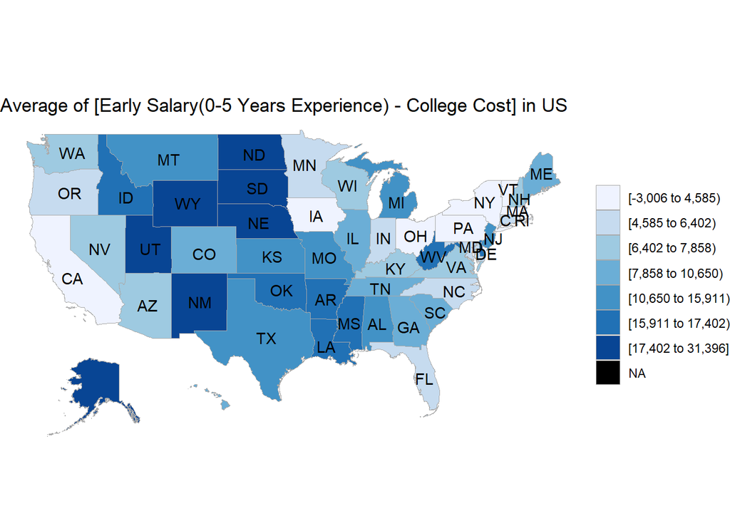

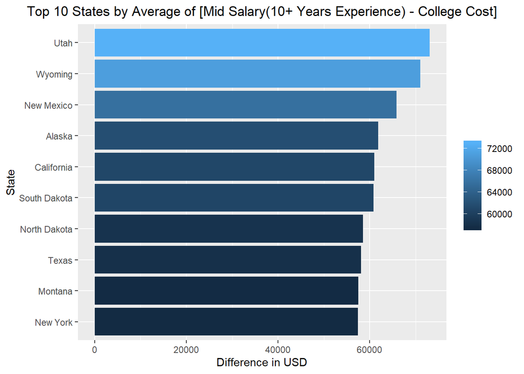

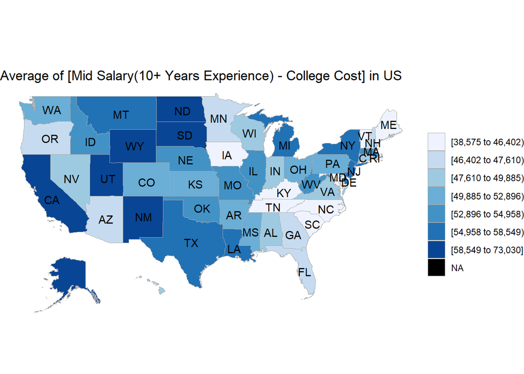

## 3, Take a look at the final data, “Final_data” at the level of school type (Private vs Public)

New dataset “School_type_data” is created from the final data, “Final_data”, by splitting into two group, “Private” and “Public”. All numeric values are summarised by taking the average respect to each type of school.

In the average Mid-career Salary(10+ Years Experience) and the average Early-Salary(0-5 Years Experience, private schools outweights public schools in the U.S. However, in the most important career performance matrics that I created, public schools really shows the advantage. Because of lower total college cost, the “Mean_early_paidoff”, which represents the average amount of [Early Salary(0-5 Years Experience) - College Cost] for public school is much higher than that in private school.

As a result, if people believe that college is a good investment, public schools should be highly considered.

| type | count | Mean_Early_Career_Pay | Mean_Mid_Career_pay | Mean_High_Meaning | Mean_STEM_Degree | Mean_Out_Of_State_Cost | Mean_Enrollment | Mean_Minority | Mean_early_paidoff | Mean_mid_paidoff |
| --- | --- | --- | --- | --- | --- | --- | --- | --- | --- | --- |
| Private | 382 | 52397.12 | 95198.95 | 53.00000 | 17.68063 | 49352.49 | 4688.406 | 1270.424 | 3044.631 | 45846.46 |
| Public | 240 | 48810.42 | 87678.33 | 54.44583 | 15.78333 | 30092.28 | 12564.783 | 3616.262 | 18718.138 | 57586.05 |

# IV. Future Development and Improvement

## 1, Create a dataset with nested states

Save for future development and improvement, such as creating linear regression model for each states to reveal siginificant impact that each factor might have on the relationship between college cost and career performance.

```r
state_nested = Final_data %>%
  group_by(state)%>%
  nest()

# One example for Linear Regression for further data analysis:
state_lm <- function(df){
  lm(Mid_career_pay_paidoff ~ out_of_state_tuition_and_fee, data = df)
}

state_nested_lm <- state_nested$data %>% map(state_lm)
#state_nested_lm[[1]]

# Put the model right back into the nested data frame
state_nested_1 = state_nested%>%
  mutate(lm_fit = map(data, state_lm))

state_nested_1 = state_nested_1%>%
  mutate(lm_glance = map(lm_fit, glance))
```

## 2, More data needed

When comparing schools with different length of degrees, the comparison could be bias because there are only 2 schools with length of degrees as 2 year.

As for improvement, more schools with 2 year degrees in the U.S. should be added into the dataset.

| degree_length | count | Mean_Early_Career_Pay | Mean_Mid_Career_pay | Mean_High_Meaning | Mean_STEM_Degree | Mean_Out_Of_State_Cost | Mean_Enrollment | Mean_Minority | Mean_early_paidoff | Mean_mid_paidoff |
| --- | --- | --- | --- | --- | --- | --- | --- | --- | --- | --- |
| 2 Year | 2 | 43400.00 | 76850.00 | 61.50000 | 8.50000 | 10304.50 | 8227.000 | 2618.500 | 33095.500 | 66545.50 |
| 4 Year | 620 | 51037.74 | 92346.94 | 53.53226 | 16.97581 | 42022.89 | 7725.911 | 2174.142 | 9014.856 | 50324.05 |